# Trabajo Final R

Andrea Calvo Martínez,Alejandro Esteban Loza, Fabian C. Gomez L., María José Aparicio Zarco, Paulina Camet Rosemberg

14/12/2020

# 1) Importar bases de datos en R y hacer las comprobaciones pertinentes

Limpiamos y reordenamos la base de datos

```r
setwd("C:/Users/Fabi/Desktop/EAE/Clases/Business Performance Analysis (R)/Proyecto")
Datos_Compradores <- read.csv("Dataset_Compradores.csv", header = T, sep = ",")

Datos_Compradores <- Datos_Compradores[,-c(1,14)] %>%
    rename(ID_Cliente = CustomerId, Apellidos = Surname, Pais = Geography, Genero = Gender,
           Edad = Age, Tiempo_Restante=Tenure, Numero_Productos = NumOfProducts,
           Tarjeta_Credito = HasCrCard, Miembro_Activo = IsActiveMember, Salario_Estimado = EstimatedSalary)
```

Exploramos nuestra tabla para comprobar la validez de los datos

```r
head(Datos_Compradores)
```

```
##   ID_Cliente Apellidos CreditScore   Pais Genero Edad Tiempo_Restante   Balance
## 1   15634602  Hargrave         619 France Female   42               2      0.00
## 2   15647311      Hill         608  Spain Female   41               1  83807.86
## 3   15619304      Onio         502 France Female   42               8 159660.80
## 4   15701354      Boni         699 France Female   39               1      0.00
## 5   15737888  Mitchell         850  Spain Female   43               2 125510.82
## 6   15574012       Chu         645  Spain   Male   44               8 113755.78
##   Numero_Productos Tarjeta_Credito Miembro_Activo Salario_Estimado
## 1                1               1              1        101348.88
## 2                1               0              1        112542.58
## 3                3               1              0        113931.57
## 4                2               0              0         93826.63
## 5                1               1              1         79084.10
## 6                2               1              0        149756.71
```

```r
tail(Datos_Compradores)
```

```
##       ID_Cliente Apellidos CreditScore    Pais Genero Edad Tiempo_Restante
## 9995    15719294      Wood         800  France Female   29               2
## 9996    15606229  Obijiaku         771  France   Male   39               5
## 9997    15569892 Johnstone         516  France   Male   35              10
## 9998    15584532       Liu         709  France Female   36               7
## 9999    15682355 Sabbatini         772 Germany   Male   42               3
## 10000   15628319    Walker         792  France Female   28               4
##         Balance Numero_Productos Tarjeta_Credito Miembro_Activo
## 9995       0.00                2               0              0
## 9996       0.00                2               1              0
## 9997   57369.61                1               1              1
## 9998       0.00                1               0              1
## 9999   75075.31                2               1              0
## 10000 130142.79                1               1              0
##       Salario_Estimado
## 9995         167773.55
## 9996          96270.64
## 9997         101699.77
## 9998          42085.58
## 9999          92888.52
## 10000         38190.78
```

Observamos el tipo de variables con las que vamos a trabajar

```r
  str(Datos_Compradores)
```

```
## 'data.frame':    10000 obs. of  12 variables:
##  $ ID_Cliente      : int  15634602 15647311 15619304 15701354 15737888 15574012 15592531 15656148 15792365 15592389 ...
##  $ Apellidos       : chr  "Hargrave" "Hill" "Onio" "Boni" ...
##  $ CreditScore     : int  619 608 502 699 850 645 822 376 501 684 ...
##  $ Pais            : chr  "France" "Spain" "France" "France" ...
##  $ Genero          : chr  "Female" "Female" "Female" "Female" ...
##  $ Edad            : int  42 41 42 39 43 44 50 29 44 27 ...
##  $ Tiempo_Restante : int  2 1 8 1 2 8 7 4 4 2 ...
##  $ Balance         : num  0 83808 159661 0 125511 ...
##  $ Numero_Productos: int  1 1 3 2 1 2 2 4 2 1 ...
##  $ Tarjeta_Credito : int  1 0 1 0 1 1 1 1 0 1 ...
##  $ Miembro_Activo  : int  1 1 0 0 1 0 1 0 1 1 ...
##  $ Salario_Estimado: num  101349 112543 113932 93827 79084 ...
```

```r
  class(Datos_Compradores$ID_Cliente)
```

```
## [1] "integer"
```

```r
  class(Datos_Compradores$Apellidos)
```

```
## [1] "character"
```

```r
  class(Datos_Compradores$Salario_Estimado)
```

```
## [1] "numeric"
```

Resumen estadístico descriptivo de las variables

```r
  summary(Datos_Compradores)
```

```
##    ID_Cliente        Apellidos          CreditScore        Pais
##  Min.   :15565701   Length:10000       Min.   :350.0   Length:10000
##  1st Qu.:15628528   Class :character   1st Qu.:584.0   Class :character
##  Median :15690738   Mode  :character   Median :652.0   Mode  :character
##  Mean   :15690941                      Mean   :650.5
##  3rd Qu.:15753234                      3rd Qu.:718.0
##  Max.   :15815690                      Max.   :850.0
##     Genero               Edad       Tiempo_Restante     Balance
##  Length:10000       Min.   :18.00   Min.   : 0.000   Min.   :     0
##  Class :character   1st Qu.:32.00   1st Qu.: 3.000   1st Qu.:     0
##  Mode  :character   Median :37.00   Median : 5.000   Median : 97199
##                     Mean   :38.92   Mean   : 5.013   Mean   : 76486
##                     3rd Qu.:44.00   3rd Qu.: 7.000   3rd Qu.:127644
##                     Max.   :92.00   Max.   :10.000   Max.   :250898
##  Numero_Productos Tarjeta_Credito  Miembro_Activo   Salario_Estimado
##  Min.   :1.00     Min.   :0.0000   Min.   :0.0000   Min.   :    11.58
##  1st Qu.:1.00     1st Qu.:0.0000   1st Qu.:0.0000   1st Qu.: 51002.11
##  Median :1.00     Median :1.0000   Median :1.0000   Median :100193.91
##  Mean   :1.53     Mean   :0.7055   Mean   :0.5151   Mean   :100090.24
##  3rd Qu.:2.00     3rd Qu.:1.0000   3rd Qu.:1.0000   3rd Qu.:149388.25
##  Max.   :4.00     Max.   :1.0000   Max.   :1.0000   Max.   :199992.48
```

# 2) Describir de manera gráfica y estadistica las variables de la base de datos

## **Credit Score**

### a) *Definición fundamental*

```r
class(Datos_Compradores$CreditScore)
```

```
## [1] "integer"
```

```r
length(Datos_Compradores$CreditScore)
```

```
## [1] 10000
```

```r
describe(Datos_Compradores$CreditScore)
```

```
##    vars     n   mean    sd median trimmed   mad min max range  skew kurtosis
## X1    1 10000 650.53 96.65    652  651.01 99.33 350 850   500 -0.07    -0.43
##      se
## X1 0.97
```

Variable cuantitativa discreta de tipo entero la cual nos brinda información sobre el nivel de solvencia de los clientes. Es un valor que se asigna a cada cliente según su historial de pagos, puntualidad de pagos, deudas, préstamos y otros valores financieros. Es un valor que afecta las posibilidades de una persona de recibir un préstamo, alquilar un departamento, entre otros. Un mayor nivel de crédito, es una calificación más alta, lo que demuestra una mejor situación del cliente y le ofrece mejores servicios y condiciones.

### b) *Representación gráfica*

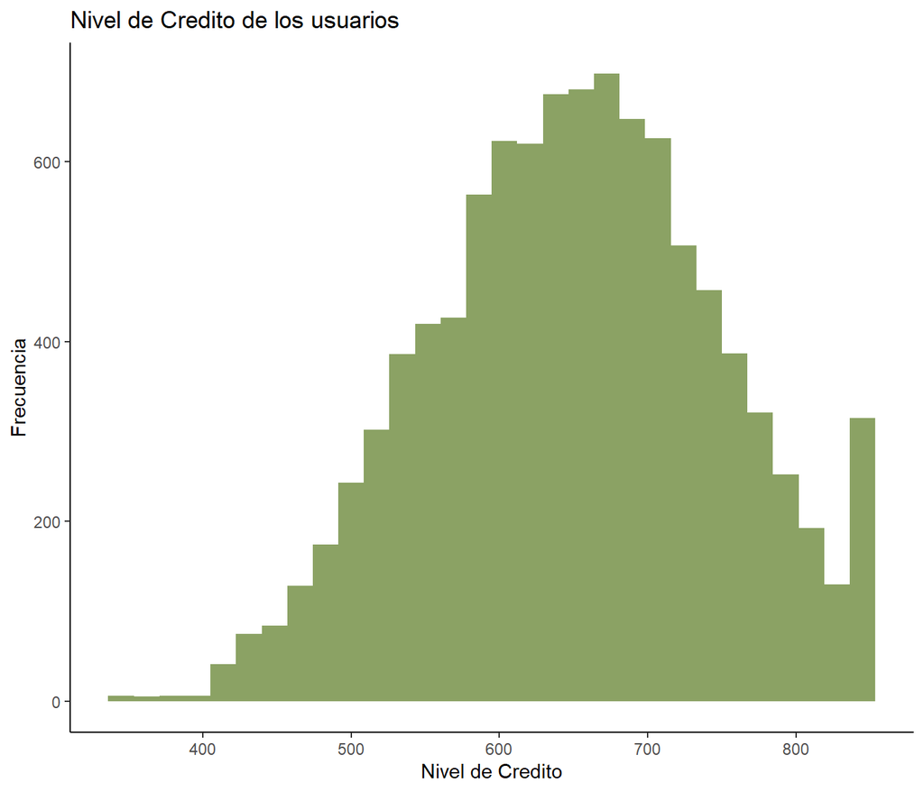

```r
ggplot(data = Datos_Compradores) +
    geom_histogram(mapping = aes(x = CreditScore),fill="darkolivegreen4", alpha=0.8) +
    labs(title = 'Nivel de Credito de los usuarios',
           x = 'Nivel de Credito',
           y = 'Frecuencia') + theme_classic()
```

En este caso no se realiza una Tabla de Frecuencias ya que la cantidad de valores que toma la variable es muy alta y se distribuye en un rango amplio de 500 unidades, lo que no permite hacer un análisis rápido.

Por lo tanto, se optó por graficar la variable con un histograma, el cual permite visualizar todo el recorrido de la variable.

### c) *Medidas de posición y dispersión*

```r
describe(Datos_Compradores$CreditScore)
```

```
##    vars     n   mean    sd median trimmed   mad min max range  skew kurtosis
## X1    1 10000 650.53 96.65    652  651.01 99.33 350 850   500 -0.07    -0.43
##      se
## X1 0.97
```

### d) *Medidas de posición*

- Cuantiles

```r
IQR(Datos_Compradores$CreditScore)
```

```
## [1] 134
```

```r
quantile(Datos_Compradores$CreditScore)
```

```
##   0%  25%  50%  75% 100%
##  350  584  652  718  850
```

Los valores de Credit Score menores a 383 se consideran valores atípicos en la distribución de la variable.

### d) *Análisis de la variable*

El valor más representativo de la variable Credit Score es la media, equivalente a un nivel de crédito de 650.52. Se seleccionó la media como el valor central representativo de esta variable ya que no hay una alta presencia de valores extremos que distorsionan la muestra.

Se considera que el valor central de la media es representante de la variable ya que la desviación estándar, indicando la distancia típica de los valores a la media, equivalente a 96.65, se considera pequeña al estar dentro de un rango amplio. Por lo tanto, la distribución de la variable es pequeña y el valor de la media es representativo de la muestra.

Los valores de asimetría y curtosis son menores a 2 y menor a 7 respectivamente (en valor absoluto), por lo que se considera que la distribución de la variable se aproxima a una distribución normal. De este modo, se estima que el 95% de los valores se encuentran a no más de dos desviaciones estándares de la media.

Sin embargo, debemos tener en consideración, la alta frecuencia del valor más alto de la variable, 850, el cual tiene 233 clientes de la muestra con dicho Credit Score. Por lo que se sesga la conclusión de distribución normal de la variable, pues en este caso no se cumple del todo que los valores centrales son más probables que los que se van alejando del centro.

Los valores de Credit Score menores a 383 se consideran valores atípicos en la distribución de la variable.

## **Segmentación Credit Score**

Decidimos agrupar los datos de la variable Credit Score para facilitar su análisis. Esto es una práctica que generalmente se realiza en bancos y entidades para poder categorizar a los clientes según su calificación de crédito y según cada categoría ofrecerles diferentes servicios y beneficios. Además, al ser el Credit Score una variable que puede tomar una gran cantidad de valores debido a su alto rango, categorizarlos permite facilitar su análisis.

```r
range(Datos_Compradores$CreditScore)
```

```
## [1] 350 850
```

```r
Datos_Compradores$Segmentacion_CreditScore <- NA
Datos_Compradores$Segmentacion_CreditScore[which(Datos_Compradores$CreditScore > 300 & Datos_Compradores$CreditScore < 500)] <- 'Muy Bajo'
Datos_Compradores$Segmentacion_CreditScore[which(Datos_Compradores$CreditScore >= 500 & Datos_Compradores$CreditScore <= 600)] <- 'Bajo'
Datos_Compradores$Segmentacion_CreditScore[which(Datos_Compradores$CreditScore > 600 & Datos_Compradores$CreditScore <= 660)] <- 'Medio'
Datos_Compradores$Segmentacion_CreditScore[which(Datos_Compradores$CreditScore >= 661 & Datos_Compradores$CreditScore <= 780)] <- 'Bueno'
Datos_Compradores$Segmentacion_CreditScore[which(Datos_Compradores$CreditScore >= 781)] <- 'Muy Bueno'
table(Datos_Compradores$Segmentacion_CreditScore)
```

```
##
##      Bajo     Bueno     Medio  Muy Bajo Muy Bueno
##      2434      3703      2281       632       950
```

Al segmentar la variable credit score, se convierte en una variable cualitativa categórica. Nos brinda información sobre la solvencia de los clientes agrupándolos en las siguientes categorías según su Crédito Score: muy bajo, bajo, medio, bueno, muy bueno.

- Convertimos en factor los datos obtenidos en nuestra variable de Segmentación de ‘Credit Score’ y reordenamos

```r
Datos_Compradores$Segmentacion_CreditScore <- factor(Datos_Compradores$Segmentacion_CreditScore,
                                                        levels = c('Muy Bajo','Bajo','Medio',
                                                                   'Bueno','Muy Bueno'))
```

- Creamos un objeto para poder asignar diferentes colores a nuestros segmentos

```r
color_barras <- c('red2','coral2','yellow1','limegreen','green4')
```

- Utilizamos un diagrama de barras para poder representarla, siendo distribuida por categorias

### a) *Representación gráfica*

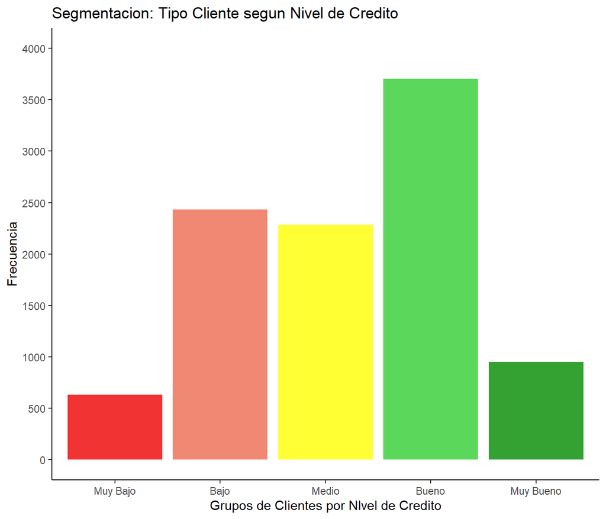

```r
ggplot(data = Datos_Compradores) +
    geom_bar(mapping = aes(x = Datos_Compradores$Segmentacion_CreditScore), fill = color_barras, alpha = 0.8) +
    labs(title = 'Segmentacion: Tipo Cliente segun Nivel de Credito',
         x ='Grupos de Clientes por NIvel de Credito',
         y = 'Frecuencia') +
    scale_y_continuous(limits = c(0, 4000), breaks = seq(0,4000,500)) +
    theme_classic()
```

### b) *Tabla Frecuencias*

```r
table(Datos_Compradores$Segmentacion_CreditScore)
```

```
##
##  Muy Bajo      Bajo     Medio     Bueno Muy Bueno
##       632      2434      2281      3703       950
```

### c) *Análisis de la variable*

Gracias al gráfico de barras observamos que la mayoría de los clientes se agrupan en un ‘Credit Score’ considerado como “Bueno”, un total de 3703 clientes. Existe un grupo mayor de clientes que lo segmentamos con un ‘Credit Score’ “Bueno” y “Muy Bueno” con respecto a los que pertenecen al grupo de “Bajo” “Muy Bajo”.

## **País**

### a) *Definición Fundamental*

```r
class(Datos_Compradores$Pais)
```

```
## [1] "character"
```

```r
length(Datos_Compradores$Pais)
```

```
## [1] 10000
```

Variable categórica nominal, la cual se distribuye en 3 valores, 3 países diferentes: Francia, España y Alemania. Esta variable indica la nacionalidad de los clientes.

### b) *Representación Gráfica*

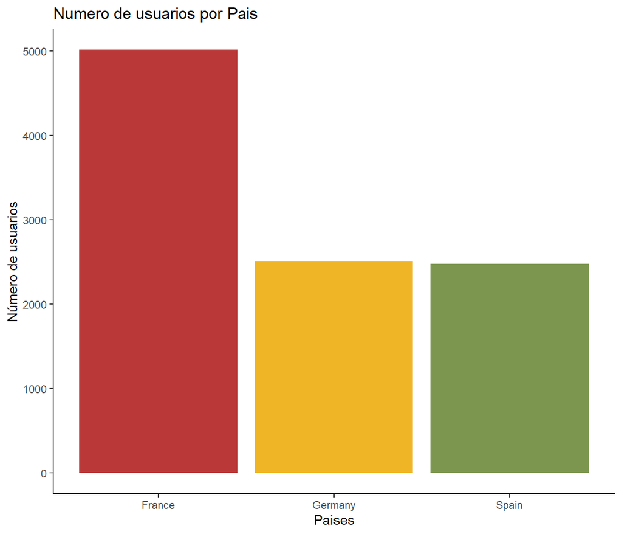

```r
color1 <- c("firebrick","darkgoldenrod2","darkolivegreen4")
ggplot(data = Datos_Compradores, aes(x = Pais)) +
    geom_bar(position = "dodge",fill=color1, alpha =0.9) +
    labs( title = "Numero de usuarios por Pais",
          x = "Paises",
          y = "Número de usuarios")+ theme_classic()
```

### c) *Tabla Frecuencias*

```r
table(Datos_Compradores$Pais)
```

```
##
##  France Germany   Spain
##    5014    2509    2477
```

Al ser una variable categórica se optó por un gráfico de barras que muestra las frecuencias de cada categoría.

La categoría de país con mayor frecuencia es Francia, aproximadamente un 50% de los clientes tiene nacionalidad francesa. Siendo la Moda de la variable, Francia.

## **Genero**

### a) *Definición Fundamental*

```r
class(Datos_Compradores$Genero)
```

```
## [1] "character"
```

```r
length(Datos_Compradores$Genero)
```

```
## [1] 10000
```

Variable categórica nominal binaria, la cual se distribuye en 2 categorías: Hombre, Mujer. Esta variable refleja la distribución del género de los clientes en la muestra.

### b) *Representación Gráfica*

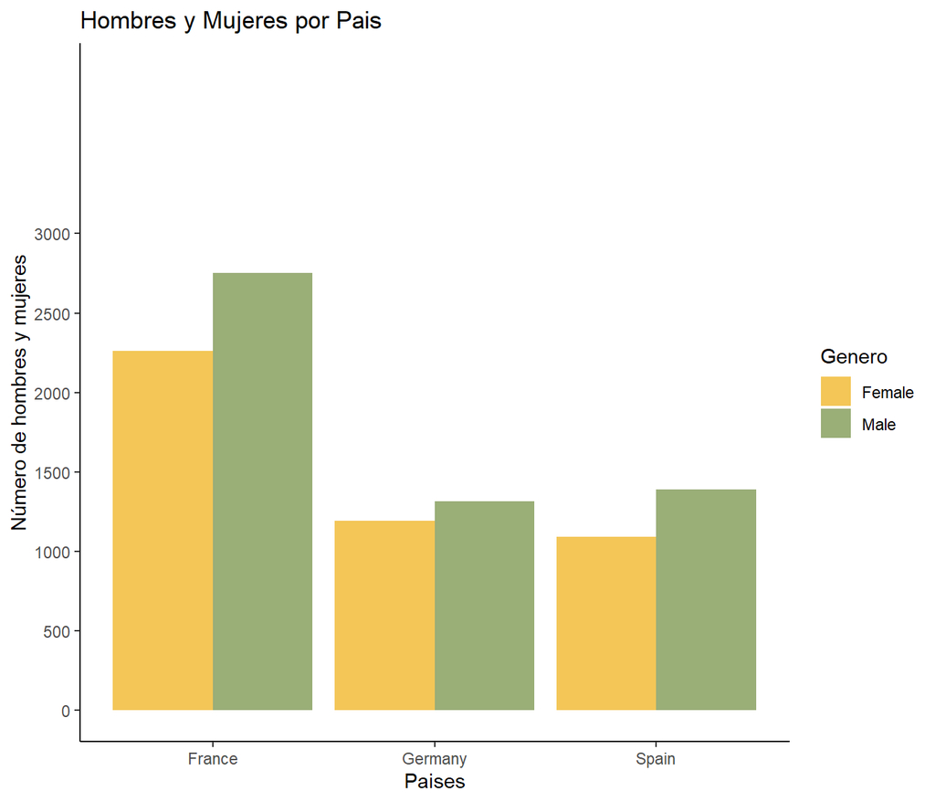

```r
Barras_Genero_Pais <- ggplot(data = Datos_Compradores, aes(x = Pais)) +
    geom_bar(aes(fill=Genero),
             position = "dodge",alpha=0.7) +
    labs( title = "Hombres y Mujeres por Pais",
          x = "Paises",
          y = "Número de hombres y mujeres") +
    scale_fill_manual(values = c('darkgoldenrod2','darkolivegreen4')) +
    theme_classic() +
    scale_y_continuous(limits = c(0, 4000), breaks = seq(0,3000,500)); Barras_Genero_Pais
```

### c) *Tabla Frecuencias*

```r
table(Datos_Compradores$Genero)
```

```
##
## Female   Male
##   4543   5457
```

Al ser una variable categórica se optó por un gráfico de barras que muestra las frecuencias de cada categoría. La frecuencia de la categoría masculino es mayor que la de femenino. Siendo una mayor cantidad de clientes de la muestra hombres. Sin embargo, la diferencia entre las frecuencias no es alta.

### d) *Análisis de la variable*

Para representar graficamente nuestra variable ‘Genero’ hacemos uso de un diagrama de barras Existe una mayor representacion de Compradores masculinos que femeninos. Para realizar una profuncización en los datos se realizó una comparación con la variable país donde se observa que francia presenta la mayor muestra de población, mientras que la proporción de hombres es mayor en los 3 paises frente a las mujeres.

## **Edad**

### a) *Definición fundamental*

```r
class(Datos_Compradores$Edad)
```

```
## [1] "integer"
```

```r
length(Datos_Compradores$Edad)
```

```
## [1] 10000
```

```r
describe(Datos_Compradores$Edad)
```

```
##    vars     n  mean    sd median trimmed mad min max range skew kurtosis  se
## X1    1 10000 38.92 10.49     37   37.91 8.9  18  92    74 1.01     1.39 0.1
```

Variable cuantitativa discreta de tipo entero con un rango de muestra amplio

### b) *Representación Gráfica*

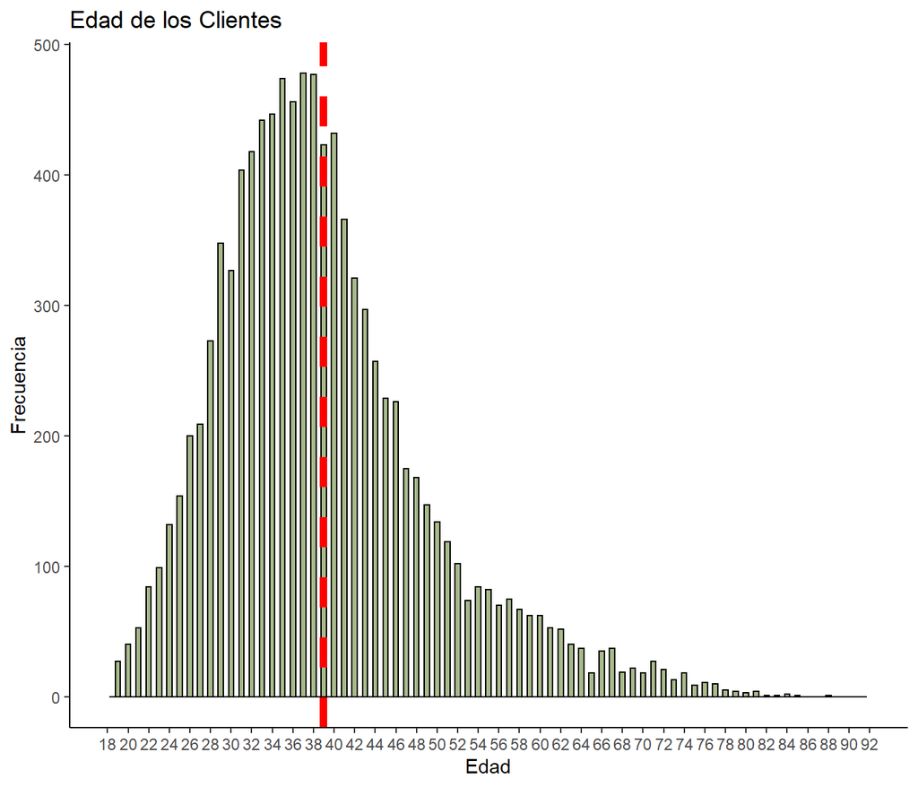

```r
Histograma_Edad <- ggplot(data = Datos_Compradores, mapping = aes(x = Edad)) +
    geom_histogram(bins = 75,
                   binwidth = 0.5,
                   color = 'black',
                   fill = 'darkolivegreen4',
                   alpha = 0.6) +
    labs(title = 'Edad de los Clientes',
         x = 'Edad',
         y = 'Frecuencia') +
    theme_classic() +
    geom_vline(aes(xintercept = mean(Edad)),
               color = 'red',
               linetype = 'dashed',
               size = 2) +
    scale_x_continuous(limits = c(18, 92), breaks = seq(18,92,2)); Histograma_Edad
```

En este caso tampoco se realiza una Tabla de Frecuencia ya que la cantidad de valores que toma la variable se distribuyen entre 18 y 92 años, equivalente a un rango amplio de 74 unidades, lo que no permite realizar un análisis rápido a través de la tabla de frecuencias..

Por lo tanto, se optó por graficar la variable con un histograma, el cual permite visualizar todo el recorrido de la variable, la cual es cuantitativa y discreta, al agruparla en intervalos.

### c) *Medidas de posición*

- Cuantiles

```r
  quantile(Datos_Compradores$Edad)
```

```
##   0%  25%  50%  75% 100%
##   18   32   37   44   92
```

- Rango intercuartilico

```r
IQR(Datos_Compradores$Edad)
```

```
## [1] 12
```

Graficamos la variable con un gráfico de cajas y bigotes para poder visualizar la distribución de la variable y la presencia de los valores atípicos y extremos.

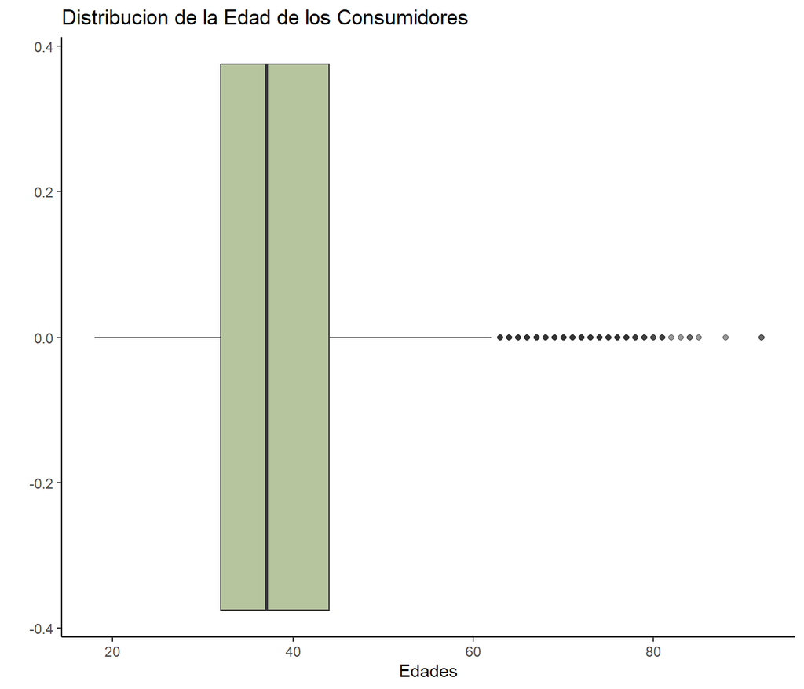

```r
  ggplot(data = Datos_Compradores, aes(x = Edad)) +
    geom_boxplot(fill="darkolivegreen4",alpha=0.5) +
    labs(title = 'Distribucion de la Edad de los Consumidores',
         x = 'Edades',
         y = '') + theme_classic()
```

### d) *Análisis de la variable*

La media de la variable Edad de los clientes es equivalente a 38.91 años y la mediana a 37 años. En este caso, consideramos que el valor más representativo de la variable es la mediana, ya que hay presencia de valores extremos los cuales distorsionan la muestra.

Se puede observar que el 75% de clientes de la muestra quedó representada desde 18 hasta los 44 años. Las edades mayores e iguales a 62 años se consideran como valores atípicos de la variable Edad ya que distan en 1.5 veces el rango intercuartílico. Asimismo, Las edades mayores e iguales a 80 años se consideran como valores extremos de la variable Edad ya que distan en 3 veces el rango intercuartílico.

## **Tenure**

### a) *Definición fundamental*

```r
class(Datos_Compradores$Tiempo_Restante)
```

```
## [1] "integer"
```

```r
length(Datos_Compradores$Tiempo_Restante)
```

```
## [1] 10000
```

```r
describe(Datos_Compradores$Tiempo_Restante)
```

```
##    vars     n mean   sd median trimmed  mad min max range skew kurtosis   se
## X1    1 10000 5.01 2.89      5    5.01 2.97   0  10    10 0.01    -1.17 0.03
```

Tenure indica el tiempo en años que un cliente tiene para pagar su deuda o prestamos. Es una variable cuantitativa discreta de tipo integer con un rango de muestra pequeño.

### b) *Representación Gráfica*

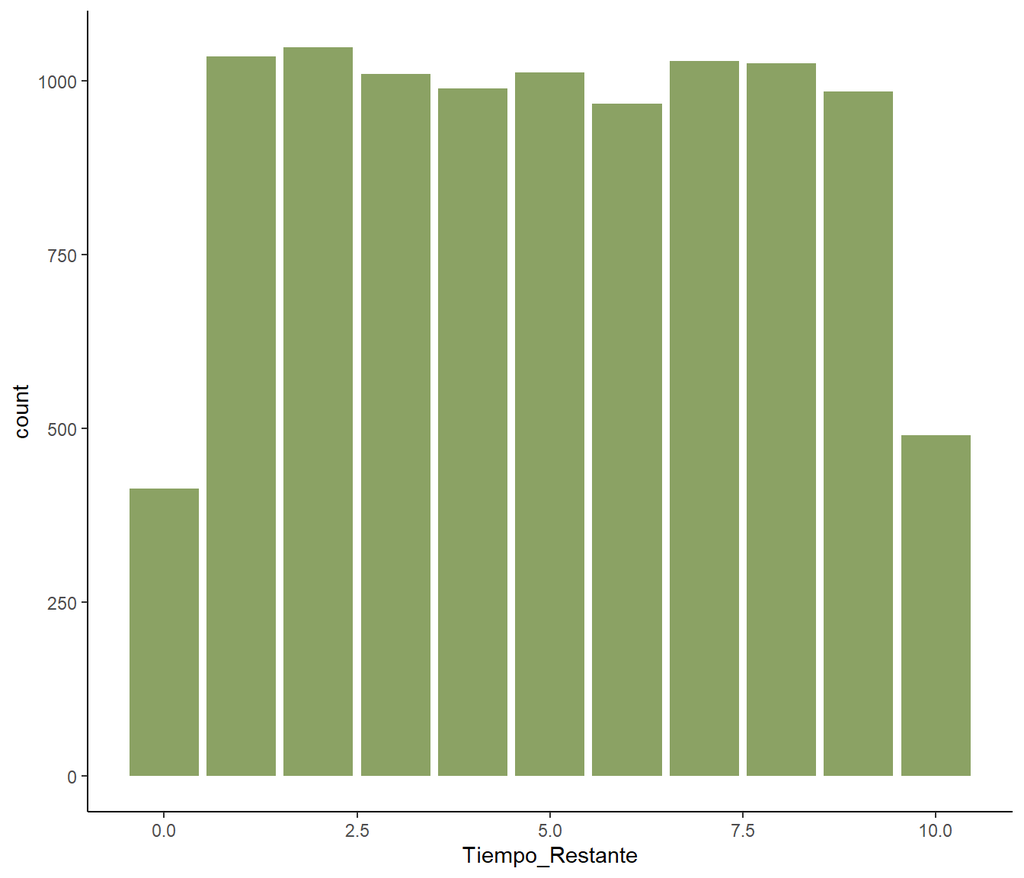

```r
Grafica_tiempo <- ggplot(Datos_Compradores ) + geom_bar(aes(x=Tiempo_Restante), fill="darkolivegreen4", alpha=0.8) +theme_classic()
Grafica_tiempo
```

### c) *Tabla de Frecuencias*

```r
table(Datos_Compradores$Tiempo_Restante)
```

```
##
##    0    1    2    3    4    5    6    7    8    9   10
##  413 1035 1048 1009  989 1012  967 1028 1025  984  490
```

Se opto por graficar la variable con un gráfico de barras, ya que es una variable cuantitativa y discreta con un rango muestral pequeño.

### d) *Medidas de Posición*

```r
IQR(Datos_Compradores$Tiempo_Restante)
```

```
## [1] 4
```

```r
quantile(Datos_Compradores$Tiempo_Restante)
```

```
##   0%  25%  50%  75% 100%
##    0    3    5    7   10
```

### e) *Análisis de la Variable*

En esta variable no existen valores atípicos ni extremos.

## **Balance**

### a) *Definición Fundamental*

```r
class(Datos_Compradores$Balance)
```

```
## [1] "numeric"
```

```r
length(Datos_Compradores$Balance)
```

```
## [1] 10000
```

```r
describe(Datos_Compradores$Balance)
```

```
##    vars     n     mean       sd   median trimmed      mad min      max    range
## X1    1 10000 76485.89 62397.41 97198.54 74827.8 69336.44   0 250898.1 250898.1
##     skew kurtosis     se
## X1 -0.14    -1.49 623.97
```

### b) *Representación Gráfica*

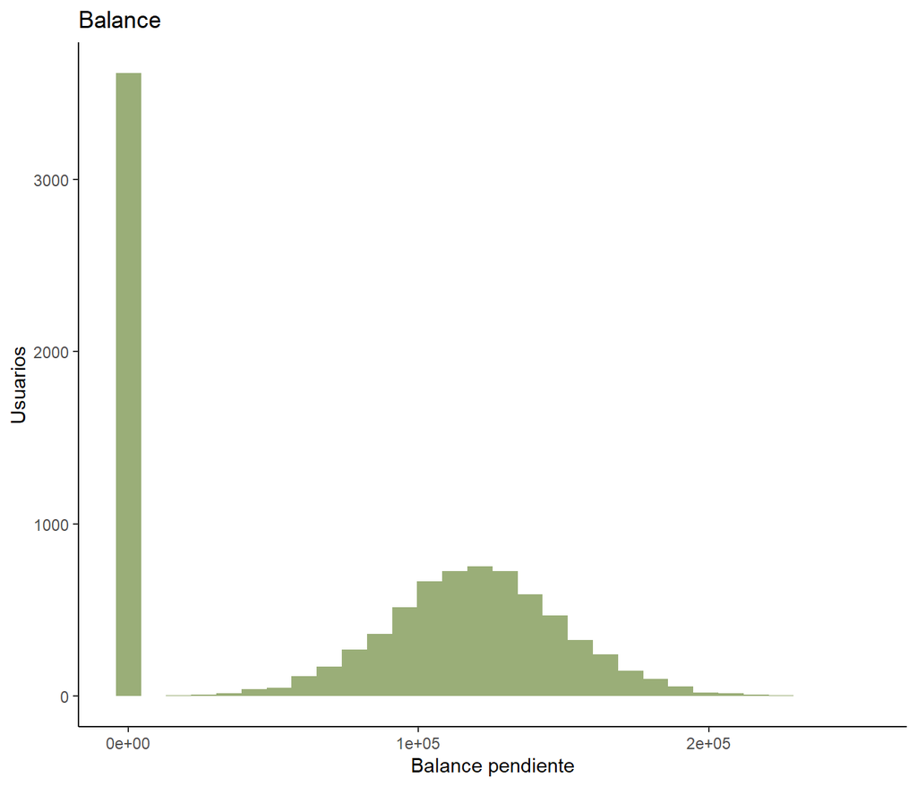

```r
ggplot(data = Datos_Compradores, aes(x = Datos_Compradores$Balance)) +
    geom_histogram(position = "dodge", fill="darkolivegreen4", alpha=0.7) +
    labs( title="Balance",
          x = "Balance pendiente",
          y = "Usuarios") + theme_classic()
```

Por lo tanto, se optó por graficar la variable con un histograma, el cual permite visualizar todo el recorrido de la variable, observándose concentración de valores en el 0, debido a que estos serían los clientes que ya no tienen deuda pendiente de pago. Mientras que en el resto de valores si se observa una distribución normal de los datos

### c) *Medidas de Posición*

```r
quantile(Datos_Compradores$Balance)
```

```
##        0%       25%       50%       75%      100%
##      0.00      0.00  97198.54 127644.24 250898.09
```

### d) *Análisis de la Variable*

El valor más representativo de la variable balance es la media, equivalente a un nivel de deuda de 76485.89 €. Sin embargo, destacar que nos encontramos con valores extremos que distorsionan la muestra, ya que hay concentración de datos en el valor 0, correspondiendose con los clientes que ya no disponen de deuda pendiente.

Varianza =: 3893436176 Desviación Estándar = 62397.41

Se considera que el valor central de la media es representante de la variable ya que la desviación estándar, indicando la distancia típica de los valores a la media, es equivalente a 62397.41, por los que la distancia de los valores respecto a la media, se encuentran próximos.

Forma de distribución (normalidad) Asimetría Negativa skew = -0.14 Gráfica Platicurtica Curtosis = -1.49

Los valores de asimetría y curtosis son menores a 2 y menor a 7 respectivamente (en valor absoluto), por lo que se considera que la variable tiene una distribución normal. De este modo, se aproxima que el 95% de los valores se encuentran a no más de dos desviaciones estándares de la media.

Sin embargo, debemos tener en consideración, la alta frecuencia del valor 0, como ya se ha mencionado, el cual tiene 3.617 clientes que no disponen de deuda. Por lo que se contradice/afecta la conclusión de distribución normal de la variable, pues en este caso no se cumple del todo que los valores centrales son más probables que los que se van alejando del centro.

## **Número_Productos**

### a) *Definición Fundamental*

```r
class(Datos_Compradores$Numero_Productos)
```

```
## [1] "integer"
```

```r
length(Datos_Compradores$Numero_Productos)
```

```
## [1] 10000
```

Número de productos es una variable que indica el número de productos que dispone un cliente, según la interpretación dada, de productos bancarios. Es una variable cuantitativa discreta de tipo integer con un rango de muestra pequeño.

### b) *Representación Gráfica*

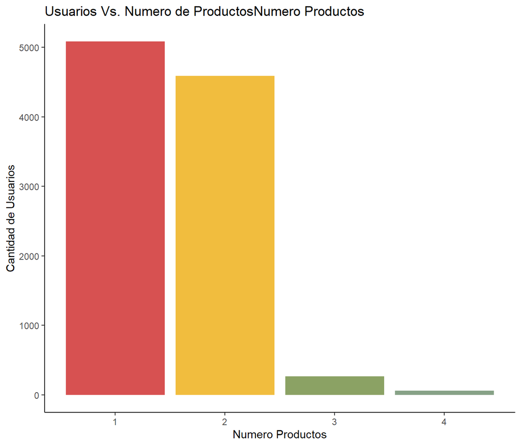

```r
color2 <- c("firebrick3","darkgoldenrod2","darkolivegreen4","darkseagreen4")
ggplot(data = Datos_Compradores, aes(x = Numero_Productos)) +
    geom_bar(position = "dodge", fill=color2, alpha=0.8) +
    labs( title="Usuarios Vs. Numero de ProductosNumero Productos",
          x = "Numero Productos",
          y = "Cantidad de Usuarios") + theme_classic()
```

Se optó por graficar la variable con un gráfico de barras, ya que es una variable cuantitativa y discreta con un rango muestral pequeño, observándose que los clientes principalmente disponen de 1 y 2 productos.

### c) *Tabla de Frecuencias*

```r
table(Datos_Compradores$Numero_Productos)
```

```
##
##    1    2    3    4
## 5084 4590  266   60
```

## **Tarjeta de Crédito**

### a) *Definición Fundamental*

```r
class(Datos_Compradores$Tarjeta_Credito)
```

```
## [1] "integer"
```

```r
length(Datos_Compradores$Tarjeta_Credito)
```

```
## [1] 10000
```

```r
describe(Datos_Compradores$Tarjeta_Credito)
```

```
##    vars     n mean   sd median trimmed mad min max range skew kurtosis se
## X1    1 10000 0.71 0.46      1    0.76   0   0   1     1 -0.9    -1.19  0
```

Variable categórica nominal binaria de tipo intenger. Esta variable se distribuye con el valor 1 para los clientes que tienen tarjeta de crédito, y 0 para los que no disponen tarjeta de crédito.

### b) *Representación Gráfica*

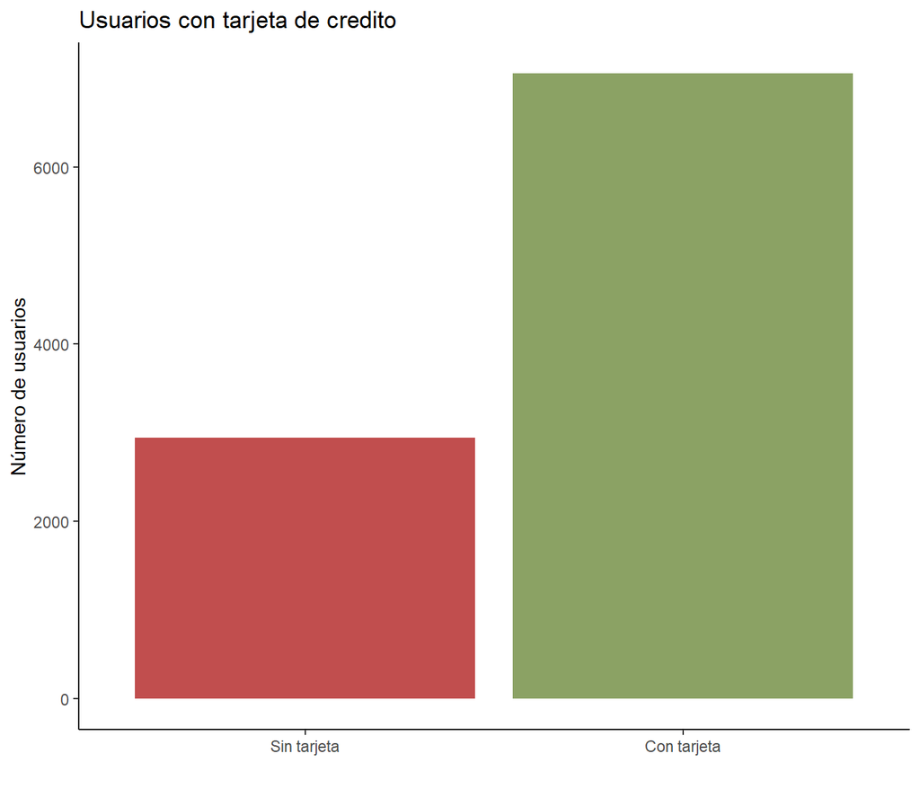

```r
tarjeta <- factor(Datos_Compradores$Tarjeta_Credito, levels = c(0,1),
                labels = c("Sin tarjeta", "Con tarjeta"))

color3 <- c("firebrick","darkolivegreen4")

ggplot(data = Datos_Compradores, aes(x = tarjeta)) +
  geom_bar(position = "dodge", fill=color3, alpha=0.8) +
  labs( title = "Usuarios con tarjeta de credito",
        x = "",
        y = "Número de usuarios") + theme_classic()
```

Al tratarse de una variable categórica se optó por un gráfico de barras que muestra las frecuencias de cada categoría. En este caso, se observa que la frecuencia que predomina es la de clientes que disponen de tarjeta de crédito frente a los que no tienen. Además, la diferencia entre las frecuentas es bastante significativa.

### c) *Tabla de Frecuencias*

```r
table(tarjeta)
```

```
## tarjeta
## Sin tarjeta Con tarjeta
##        2945        7055
```

## **Miembro Activo**

### a) *Definición Fundamental*

```r
class(Datos_Compradores$Miembro_Activo)
```

```
## [1] "integer"
```

```r
length(Datos_Compradores$Miembro_Activo)
```

```
## [1] 10000
```

```r
describe(Datos_Compradores$Miembro_Activo)
```

```
##    vars     n mean  sd median trimmed mad min max range  skew kurtosis se
## X1    1 10000 0.52 0.5      1    0.52   0   0   1     1 -0.06       -2  0
```

Al igual que en el anterior caso descrito, la variable miembros activos se trata de una variable categórica nominal binaria de tipo intenger. Esta variable se distribuye con el valor 1 para los clientes que se consideran que están activos, y 0 para los que no.

### b) *Representación Gráfica*

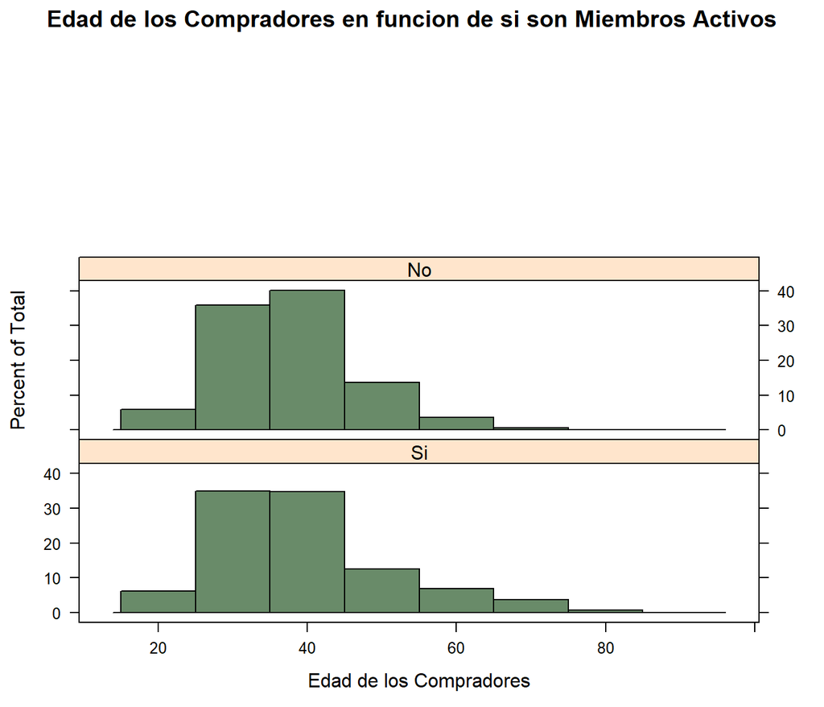

```r
Edad <- Datos_Compradores$Edad
Miembros_Activos <- factor(Datos_Compradores$Miembro_Activo, levels = c(1,0), labels = c('Si','No'))

library(lattice)
histogram(~ Edad | Miembros_Activos ,layout=c(1,3),
          xlab = 'Edad de los Compradores',
          main = 'Edad de los Compradores en funcion de si son Miembros Activos',
          breaks = seq(15,95,by=10),
          col= "darkseagreen4")
```

### c) *Tabla de Frecuencias*

```r
table(Datos_Compradores$Miembro_Activo)
```

```
##
##    0    1
## 4849 5151
```

### d) *Medidas de Posición*

```r
quantile(Datos_Compradores$Miembro_Activo)
```

```
##   0%  25%  50%  75% 100%
##    0    0    1    1    1
```

### e) *Análisis de la Variable*

Al ser una variable categórica distribuida en 1 y 0 decidimos factorizarla, por lo que aquellos miembros que tengan asignado un 1 los interpretaremos como Miembros Activos ‘Si’ mientras que los que tengan un 0 asignado serán considerados como Miembros Asignados ‘No’.

Hemos elegido un histograma para poder representar la distribución de Miembros Activos en función de la Edad de estos.

Observamos como las edades quedan repartidas en igual media tanto para aquellos que no son miembros como para los que si que son miembros. No consideramos elementos diferenciales para poder sacar conclusiones en si existe un grado de incidencia de la Edad para formar parte de la parte activa de los Miembros de nuestra base de datos.

## **Salario Estimado**

### a) *Definición Fundamental*

```r
class(Datos_Compradores$Salario_Estimado)
```

```
## [1] "numeric"
```

```r
length(Datos_Compradores$Salario_Estimado)
```

```
## [1] 10000
```

```r
describe(Datos_Compradores$Salario_Estimado)
```

```
##    vars     n     mean       sd   median  trimmed      mad   min      max
## X1    1 10000 100090.2 57510.49 100193.9 100114.9 72941.18 11.58 199992.5
##       range skew kurtosis    se
## X1 199980.9    0    -1.18 575.1
```

La variable salario estimado nos indica el salario estimado de los clientes de nuestra base de datos. Se trata de una variable cuantitativa continua de tipo numérica.

### b) *Representación Gráfica*

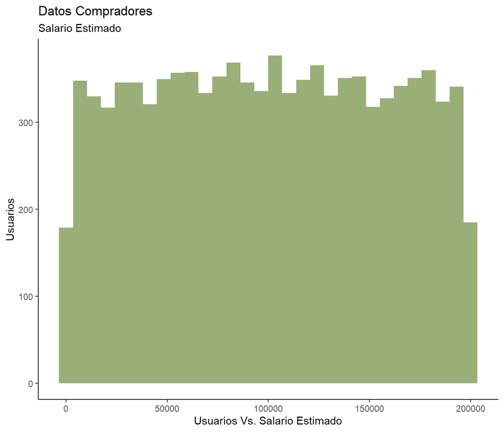

```r
ggplot(data = Datos_Compradores, aes(x = Salario_Estimado)) +
    geom_histogram(position = "dodge", fill="darkolivegreen4", alpha=0.7) +
    labs( title="Datos Compradores",
          subtitle = "Salario Estimado",
          x = "Usuarios Vs. Salario Estimado",
          y = "Usuarios") + theme_classic()
```

En este caso no se realiza una Tabla de Frecuencias ya que la cantidad de valores que toma la variable es muy alta y se distribuye en un rango amplio desde 11.58euros hasta 199992.48 euros, lo que no permite hacer una análisis rápido.

Por lo tanto, se optó por graficar la variable con un histograma. Sin embargo, el resultado no es muy visual, ya que muestra que prácticamente los valores son muy parecidos, y no se observa una distribución normal. Por lo que lo más apropiado sería graficar el salario estimado en función de otra variable, para poder obtener resultados que nos puedan aportar valor.

### c) *Medidas de Posición*

- Cuantiles

```r
  quantile(Datos_Compradores$Salario_Estimado)
```

```
##        0%       25%       50%       75%      100%
##     11.58  51002.11 100193.91 149388.25 199992.48
```

- Rango intercuartílico

```r
IQR(Datos_Compradores$Salario_Estimado)
```

```
## [1] 98386.14
```

Graficamos la variable con un diagrama de cajas y bigotes para poder visualizar la distribución de la variable y la presencia de los valores atípicos y extremos.

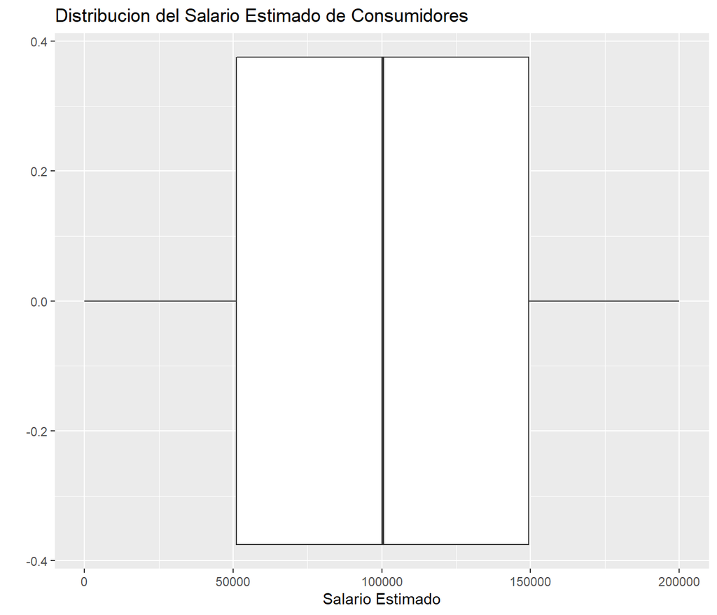

```r
  ggplot(data = Datos_Compradores, aes(x = Salario_Estimado)) +
    geom_boxplot() +
    labs(title = 'Distribucion del Salario Estimado de Consumidores',
         x = 'Salario Estimado',
         y = '')
```

### d) *Análisis de la Variable*

El valor más representativo de la variable salario es la media, equivalente a un nivel de salario estimado de 100090.2€.

Dispersión Varianza = 3307456784 Desviación Estándar = 57510.49

En este caso, se considera que el valor central de la media no es representante de la variable ya que la desviación estándar, equivalente a 57510.49, no se aproxima al valor de la media.

Forma de distribución (normalidad) Skew = 0 Gráfica Platicurtica Curtosis = -1.18

Respecto a la forma de la distribución de la variable, no se observa una distribución normal a pesar de que el valor de la asimetría es 0, indicando que es simétrica. Por el contrario, en el gráfico, se observa una distribución con forma rectangular.

Además, mencionar que no se repite ninguno de los salarios estimados en los clientes, más de una vez, por lo que no se observa alta frecuencia dentro de la variable.

Por último, mencionar que en esta variable no se observan valores atípicos ni extremos.

# 3) Llevar a cabo un analisis estadistico en R y saber interpretar los resultados.

Distribuimos los compradores de nuestra base de datos en funcion de su Pais de procedencia.

```r
Datos_Compradores_Spain <- Datos_Compradores %>%
    filter(Pais == 'Spain')
  Datos_Compradores_France <- Datos_Compradores %>%
    filter(Pais == 'France')
  Datos_Compradores_Germany <- Datos_Compradores %>%
    filter(Pais == 'Germany')
```

Analizamos las medias y desviaciones del Salario Estimado por País

```r
Datos_compradores_Paises <- data.frame(Media = c(mean(Datos_Compradores_Spain$Salario_Estimado), mean(Datos_Compradores_France$Salario_Estimado),
                                                 mean(Datos_Compradores_Germany$Salario_Estimado)),
                                       Desviacion = c (sd(Datos_Compradores_Spain$Salario_Estimado), sd(Datos_Compradores_France$Salario_Estimado),
                                                       sd(Datos_Compradores_Germany$Salario_Estimado))); Datos_compradores_Paises
```

```
##       Media Desviacion
## 1  99440.57   57103.68
## 2  99899.18   57336.29
## 3 101113.44   58263.01
```

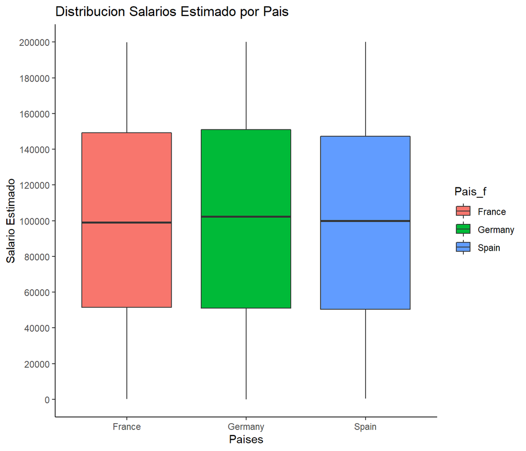

```r
Pais_f <- as.factor((Datos_Compradores$Pais))

ggplot(data = Datos_Compradores, aes(x = Pais_f, y = Salario_Estimado, fill = Pais_f)) +
  geom_boxplot() +
  labs(title = 'Distribucion Salarios Estimado por Pais',
       x = 'Paises',
       y = 'Salario Estimado') +
  scale_y_continuous(limits = c(0, 200000),
                     breaks = seq(0,200000,20000))+theme_classic()
```

## **ANOVA Test**

A continuación se muestra el análisis estadístico de comparación entre las variables país y salario.

#Al realizarse un contraste entre las variables, se definen 2 hipótesis. Se evalúa la siguiente hipótesis nula H0 y se define la hipótesis alternativa H1.

H0= “El salario de los consumidores es igual en los diferentes países donde se han recogido los datos”

H1 = “Al menos, en uno de los países donde se han recogido los datos, el salario de los consumidores es diferentes al resto de países”

Debido a que la variable categórica país tiene 3 niveles, el análisis estadístico se realiza con el ANOVA Test.

```r
Datos_Compradores_Spain <- Datos_Compradores %>%
    filter(Pais == 'Spain')
Datos_Compradores_France <- Datos_Compradores %>%
    filter(Pais == 'France')
Datos_Compradores_Germany <- Datos_Compradores %>%
    filter(Pais == 'Germany')
```

### *Supuestos*

En mi primer lugar se evalúan los supuestos que debe cumplir la muestra para poder realizar la prueba estadística ANOVA.

- HOMOCEDASTICIDAD

```r
bartlett.test(Datos_Compradores$Salario_Estimado ~ Datos_Compradores$Pais)
```

```
##
##  Bartlett test of homogeneity of variances
##
## data:  Datos_Compradores$Salario_Estimado by Datos_Compradores$Pais
## Bartlett's K-squared = 1.1953, df = 2, p-value = 0.5501
```

p = 0.5501 –> Se mantiene la hipotesis nula de igualdad de varianzas

- NORMALIDAD

```r
by(Datos_Compradores$Salario_Estimado, Datos_Compradores$Pais,describe)
```

```
## Datos_Compradores$Pais: France
##    vars    n     mean       sd   median  trimmed      mad   min      max
## X1    1 5014 99899.18 57336.29 99132.31 99906.47 72422.29 90.07 199929.2
##       range skew kurtosis     se
## X1 199839.1 0.01    -1.18 809.72
## ------------------------------------------------------------
## Datos_Compradores$Pais: Germany
##    vars    n     mean       sd   median  trimmed      mad   min      max
## X1    1 2509 101113.4 58263.01 102397.2 101219.9 74851.63 11.58 199970.7
##       range skew kurtosis      se
## X1 199959.2    0    -1.21 1163.17
## ------------------------------------------------------------
## Datos_Compradores$Pais: Spain
##    vars    n     mean       sd   median  trimmed      mad    min      max
## X1    1 2477 99440.57 57103.68 99984.86 99419.38 71969.41 417.41 199992.5
##       range  skew kurtosis      se
## X1 199575.1 -0.01    -1.17 1147.36
```

SPAIN

skew_spain = -0.01 kurtosis_spain = -1.17

FRANCIA

skew_france = 0.01 kurtosis_france = -1.18

GERMANY

skew_germany = 0 kurtosis_germany = -1.21

skew_france = 0.01 kurtosis_france = -1.18

- ```
  Shapiro Test
  ```

SPAIN

```r
ks.test(Datos_Compradores_Spain[,12], "pnorm")
```

```
##
##  One-sample Kolmogorov-Smirnov test
##
## data:  Datos_Compradores_Spain[, 12]
## D = 1, p-value < 2.2e-16
## alternative hypothesis: two-sided
```

```r
shapiro.test(Datos_Compradores_Spain[,12])
```

```
##
##  Shapiro-Wilk normality test
##
## data:  Datos_Compradores_Spain[, 12]
## W = 0.95785, p-value < 2.2e-16
```

p < 0,05 -> Se rechaza la hipótesis nula del supuesto de normalidad.

FRANCE

```r
ks.test(Datos_Compradores_France[,12], "pnorm")
```

```
##
##  One-sample Kolmogorov-Smirnov test
##
## data:  Datos_Compradores_France[, 12]
## D = 1, p-value < 2.2e-16
## alternative hypothesis: two-sided
```

p < 0,05 -> Se rechaza la hipótesis nula del supuesto de normalidad En este supuesto, no hemos utilizado el estadístico de Shapiro debido a que la muestra de Francia era elevada.

GERMANY

```r
ks.test(Datos_Compradores_Germany[,12], "pnorm")
```

```
##
##  One-sample Kolmogorov-Smirnov test
##
## data:  Datos_Compradores_Germany[, 12]
## D = 1, p-value < 2.2e-16
## alternative hypothesis: two-sided
```

```r
shapiro.test(Datos_Compradores_Germany[,12])
```

```
##
##  Shapiro-Wilk normality test
##
## data:  Datos_Compradores_Germany[, 12]
## W = 0.95319, p-value < 2.2e-16
```

p < 0,05 -> Se rechaza la hipotesis nula del supuesto de normalidad.

### *Graficamos el histogramas*

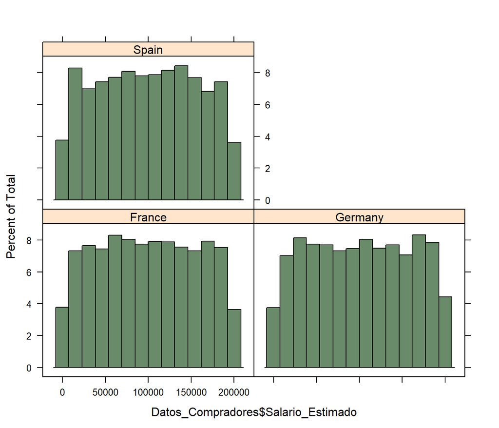

```r
library(lattice)
histogram(~Datos_Compradores$Salario_Estimado | Datos_Compradores$Pais, layout(1,3),col= "darkseagreen4")
```

En segundo lugar se evalúa es supuesto de Normalidad.

Para dicho análisis empleamos diferentes evaluaciones a traves de los valores de la curtosis y asimetria, el Shapiro Test y las graficación de cada variable con un histograma.

Es importante considerar que dicha decisión que hemos asumido de validar el supuesto normalidad con los valores de curtosis y asimetría, puede generar un sesgo en las conclusiones del análisis.

- ```
  Test
  ```

```r
by(Datos_Compradores$Salario_Estimado,Datos_Compradores$Pais,mean)
```

```
## Datos_Compradores$Pais: France
## [1] 99899.18
## ------------------------------------------------------------
## Datos_Compradores$Pais: Germany
## [1] 101113.4
## ------------------------------------------------------------
## Datos_Compradores$Pais: Spain
## [1] 99440.57
```

```r
anova(lm(Datos_Compradores$Salario_Estimado~Datos_Compradores$Pais))
```

```
## Analysis of Variance Table
##
## Response: Datos_Compradores$Salario_Estimado
##                          Df     Sum Sq    Mean Sq F value Pr(>F)
## Datos_Compradores$Pais    2 3.8552e+09 1927617402  0.5828 0.5584
## Residuals              9997 3.3067e+13 3307732835
```

p = 0.5584 –> se mantiene la hipotesis de que las medias de los 3 paises son iguales.

- ```
  Test
  ```

- ```
  Dataframe resumen (valores de media y rango de cada país)
  ```

```r
Datos_compradores_Paises <- data.frame(Media = c(mean(Datos_Compradores_Spain$Salario_Estimado), mean(Datos_Compradores_France$Salario_Estimado),
                                                  mean(Datos_Compradores_Germany$Salario_Estimado)),
                                        Desviacion = c (sd(Datos_Compradores_Spain$Salario_Estimado), sd(Datos_Compradores_France$Salario_Estimado),
                                                        sd(Datos_Compradores_Germany$Salario_Estimado))); Datos_compradores_Paises
```

```
##       Media Desviacion
## 1  99440.57   57103.68
## 2  99899.18   57336.29
## 3 101113.44   58263.01
```

- Gráficas
- Gráficas de cada país

```r
Datos_Compradores$Salario_Estimado~Datos_Compradores$Pais
```

```
## Datos_Compradores$Salario_Estimado ~ Datos_Compradores$Pais
```

- Scriptchart

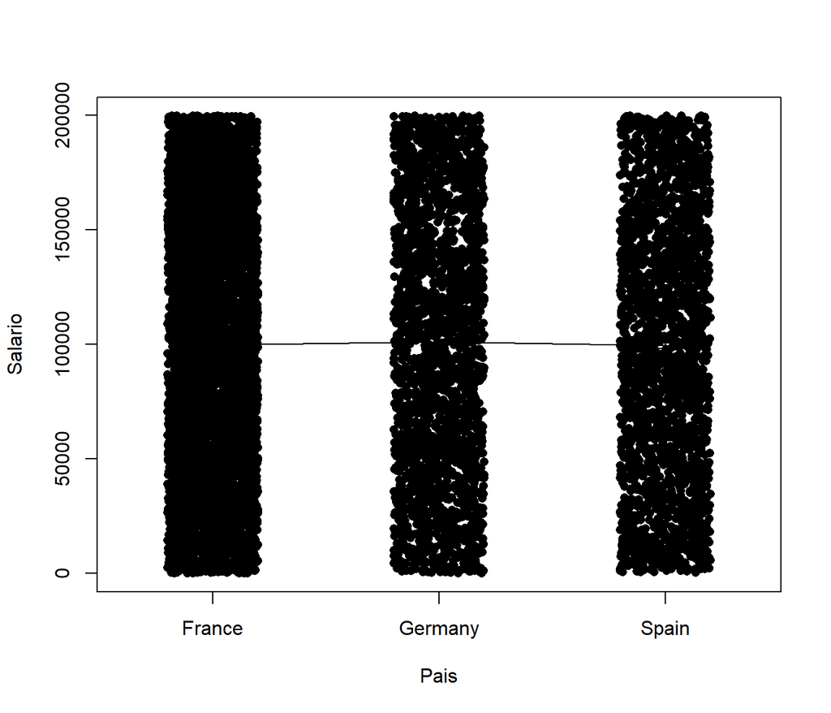

```r
grafico <- stripchart(Datos_Compradores$Salario_Estimado~ Datos_Compradores$Pais,pch=16, vert=T, method="jitter",
            jitter=0.2, xlab = "Pais", ylab ="Salario")

medias <- tapply(Datos_Compradores$Salario_Estimado,Datos_Compradores$Pais, mean)
s <- tapply(Datos_Compradores$Salario_Estimado,Datos_Compradores$Pais, sd)
n <- tapply(Datos_Compradores$Salario_Estimado,Datos_Compradores$Pais, length)
sem <- s/sqrt(n)

grafico <- arrows(1:3,medias+sem,1:3,medias-sem,angle=90,
       code=3,length=.1)
grafico <- lines(1:3,medias)
```

Al realizar la prueba estadística de ANOVA se obtiene un valor p equivalente a 0.5584, por lo tanto se mantiene la hipótesis nula de que las medías de los 3 países son iguales.

De este modo, se puede concluir que el salario de los consumidores es igual en los diferentes países donde se han recogido los datos de la muestra. Dicha conclusión se puede observar en el gráfico que une las tres medias de las distribuciones de los diferentes países. Es importante recalcar que esta conclusión se puede ver sesgada por el supuesto de normalidad.Por lo tanto, recomendamos utilizar un estadistico no paramétrico para realizar este contraste que nos pueda aportar resultados mas fiables.